# Table of Contents

任务2 - 特征工程（2天）

- 特征衍生
- 特征挑选：分别用IV值和随机森林等进行特征选择
- ……以及你能想到特征工程处理

```python
ls
```

```
2019-08-09/              data.csv                 task01_52_lmingzhi.html
README.md                others/                  task02.ipynb
Untitled.ipynb           task01.ipynb
```

## import

```python
import json, io, re, os, time
from datetime import datetime, timedelta
from pandas.io.json import json_normalize
import pandas as pd
import numpy as np
```

```python
import matplotlib.pyplot as plt
import seaborn

from collections import defaultdict, Counter
%matplotlib inline

# plt.rc('figure', figsize = (8.4,5))
# plt.rcParams['font.family'] = ['Arial Unicode MS']
# plt.rcParams['axes.unicode_minus'] = False
```

```python
# 设置显示行数
pd.set_option('display.max_rows', 100)
pd.set_option('display.max_columns', 100)
# 限制列宽，每列最多显示15个字符
# pd.set_option('display.max_colwidth', 15)
```

# 划分数据集

```python
# !head -2 data.csv
```

```python
df = pd.read_csv('data.csv', encoding='gb18030')
```

```python
df.shape
```

```
(4754, 90)
```

```python
df.columns
```

```
Index(['Unnamed: 0', 'custid', 'trade_no', 'bank_card_no',
       'low_volume_percent', 'middle_volume_percent',
       'take_amount_in_later_12_month_highest',
       'trans_amount_increase_rate_lately', 'trans_activity_month',
       'trans_activity_day', 'transd_mcc', 'trans_days_interval_filter',
       'trans_days_interval', 'regional_mobility', 'student_feature',
       'repayment_capability', 'is_high_user', 'number_of_trans_from_2011',
       'first_transaction_time', 'historical_trans_amount',
       'historical_trans_day', 'rank_trad_1_month', 'trans_amount_3_month',
       'avg_consume_less_12_valid_month', 'abs',
       'top_trans_count_last_1_month', 'avg_price_last_12_month',
       'avg_price_top_last_12_valid_month', 'reg_preference_for_trad',
       'trans_top_time_last_1_month', 'trans_top_time_last_6_month',
       'consume_top_time_last_1_month', 'consume_top_time_last_6_month',
       'cross_consume_count_last_1_month',
       'trans_fail_top_count_enum_last_1_month',
       'trans_fail_top_count_enum_last_6_month',
       'trans_fail_top_count_enum_last_12_month',
       'consume_mini_time_last_1_month',
       'max_cumulative_consume_later_1_month',
       'max_consume_count_later_6_month',
       'railway_consume_count_last_12_month',
       'pawns_auctions_trusts_consume_last_1_month',
       'pawns_auctions_trusts_consume_last_6_month',
       'jewelry_consume_count_last_6_month', 'status', 'source',
       'first_transaction_day', 'trans_day_last_12_month', 'id_name',
       'apply_score', 'apply_credibility', 'query_org_count',
       'query_finance_count', 'query_cash_count', 'query_sum_count',
       'latest_query_time', 'latest_one_month_apply',
       'latest_three_month_apply', 'latest_six_month_apply', 'loans_score',
       'loans_credibility_behavior', 'loans_count', 'loans_settle_count',
       'loans_overdue_count', 'loans_org_count_behavior',
       'consfin_org_count_behavior', 'loans_cash_count',
       'latest_one_month_loan', 'latest_three_month_loan',
       'latest_six_month_loan', 'history_suc_fee', 'history_fail_fee',
       'latest_one_month_suc', 'latest_one_month_fail', 'loans_long_time',
       'loans_latest_time', 'loans_credit_limit', 'loans_credibility_limit',
       'loans_org_count_current', 'loans_product_count', 'loans_max_limit',
       'loans_avg_limit', 'consfin_credit_limit', 'consfin_credibility',
       'consfin_org_count_current', 'consfin_product_count',
       'consfin_max_limit', 'consfin_avg_limit', 'latest_query_day',
       'loans_latest_day'],
      dtype='object')
```

```python
del df['Unnamed: 0']
```

```python
df.head(3).T
```

|  | 0 | 1 | 2 |
| --- | --- | --- | --- |
| custid | 2791858 | 534047 | 2849787 |
| trade_no | 20180507115231274000000023057383 | 20180507121002192000000023073000 | 20180507125159718000000023114911 |
| bank_card_no | 卡号1 | 卡号1 | 卡号1 |
| low_volume_percent | 0.01 | 0.02 | 0.04 |
| middle_volume_percent | 0.99 | 0.94 | 0.96 |
| take_amount_in_later_12_month_highest | 0 | 2000 | 0 |
| trans_amount_increase_rate_lately | 0.9 | 1.28 | 1 |
| trans_activity_month | 0.55 | 1 | 1 |
| trans_activity_day | 0.313 | 0.458 | 0.114 |
| transd_mcc | 17 | 19 | 13 |
| trans_days_interval_filter | 27 | 30 | 68 |
| trans_days_interval | 26 | 14 | 22 |
| regional_mobility | 3 | 4 | 1 |
| student_feature | NaN | 1 | NaN |
| repayment_capability | 19890 | 16970 | 9710 |
| is_high_user | 0 | 0 | 0 |
| number_of_trans_from_2011 | 30 | 23 | 9 |
| first_transaction_time | 2.01308e+07 | 2.01604e+07 | 2.01706e+07 |
| historical_trans_amount | 149050 | 302910 | 11520 |
| historical_trans_day | 151 | 224 | 31 |
| rank_trad_1_month | 0.4 | 0.35 | 1 |
| trans_amount_3_month | 34030 | 10590 | 5710 |
| avg_consume_less_12_valid_month | 7 | 5 | 5 |
| abs | 3920 | 6950 | 840 |
| top_trans_count_last_1_month | 0.15 | 0.05 | 0.65 |
| avg_price_last_12_month | 1020 | 1210 | 570 |
| avg_price_top_last_12_valid_month | 0.55 | 0.5 | 0.65 |
| reg_preference_for_trad | 一线城市 | 一线城市 | 一线城市 |
| trans_top_time_last_1_month | 4 | 13 | 0 |
| trans_top_time_last_6_month | 19 | 30 | 68 |

[output cut: 59 more lines]

## 目标 status

```python
df.status.fillna('null').value_counts()
```

```
0    3561
1    1193
Name: status, dtype: int64
```

## 划分数据集

```python
# conda install sklearn
from sklearn.model_selection import train_test_split
```

```python
train_set, test_set = train_test_split(df, test_size = 0.3, random_state=2018)
```

```python
train_set.shape
```

```
(3327, 89)
```

```python
test_set.shape
```

```
(1427, 89)
```

```python
df.shape
```

```
(4754, 89)
```

## 数据类型

```python
# 数据类型数量
train_set.dtypes.value_counts()
```

```
float64    70
int64      12
object      7
dtype: int64
```

### object

```python
df_types = train_set.dtypes
cond = df_types == 'object'
df_types[cond].index
```

```
Index(['trade_no', 'bank_card_no', 'reg_preference_for_trad', 'source',
       'id_name', 'latest_query_time', 'loans_latest_time'],
      dtype='object')
```

```python
test_set[df_types[cond].index].head(3).T
```

|  | 2248 | 3959 | 2251 |
| --- | --- | --- | --- |
| trade_no | 20180507115658623000000388217488 | 20180507115833078000000388221695 | 20180504175527473000000021273393 |
| bank_card_no | 卡号1 | 卡号1 | 卡号1 |
| reg_preference_for_trad | 一线城市 | 一线城市 | 一线城市 |
| source | xs | xs | xs |
| id_name | 郭二燊 | 明磊 | 王维策 |
| latest_query_time | 2018-04-13 | 2018-04-14 | 2018-04-24 |
| loans_latest_time | 2018-05-01 | 2018-03-26 | 2018-04-15 |

### int64

```python
df_types = train_set.dtypes
cond = df_types == 'int64'
df_types[cond].index
```

```
Index(['custid', 'take_amount_in_later_12_month_highest',
       'repayment_capability', 'is_high_user', 'historical_trans_amount',
       'trans_amount_3_month', 'abs', 'avg_price_last_12_month',
       'max_cumulative_consume_later_1_month',
       'pawns_auctions_trusts_consume_last_1_month',
       'pawns_auctions_trusts_consume_last_6_month', 'status'],
      dtype='object')
```

```python
test_set[df_types[cond].index].head(3).T
```

|  | 2248 | 3959 | 2251 |
| --- | --- | --- | --- |
| custid | 2179871 | 2689718 | 47426 |
| take_amount_in_later_12_month_highest | 0 | 1500 | 3000 |
| repayment_capability | 4650 | 2540 | 28160 |
| is_high_user | 0 | 0 | 0 |
| historical_trans_amount | 168590 | 227470 | 959780 |
| trans_amount_3_month | 23060 | 43810 | 114140 |
| abs | 19020 | 10040 | 6110 |
| avg_price_last_12_month | 1580 | 1240 | 1660 |
| max_cumulative_consume_later_1_month | 0 | 1970 | 2290 |
| pawns_auctions_trusts_consume_last_1_month | 0 | 0 | 1150 |
| pawns_auctions_trusts_consume_last_6_month | 21920 | 28890 | 90330 |
| status | 0 | 0 | 1 |

### float64

```python
df_types = train_set.dtypes
cond = df_types == 'float64'
df_types[cond].index
```

```
Index(['low_volume_percent', 'middle_volume_percent',
       'trans_amount_increase_rate_lately', 'trans_activity_month',
       'trans_activity_day', 'transd_mcc', 'trans_days_interval_filter',
       'trans_days_interval', 'regional_mobility', 'student_feature',
       'number_of_trans_from_2011', 'first_transaction_time',
       'historical_trans_day', 'rank_trad_1_month',
       'avg_consume_less_12_valid_month', 'top_trans_count_last_1_month',
       'avg_price_top_last_12_valid_month', 'trans_top_time_last_1_month',
       'trans_top_time_last_6_month', 'consume_top_time_last_1_month',
       'consume_top_time_last_6_month', 'cross_consume_count_last_1_month',
       'trans_fail_top_count_enum_last_1_month',
       'trans_fail_top_count_enum_last_6_month',
       'trans_fail_top_count_enum_last_12_month',
       'consume_mini_time_last_1_month', 'max_consume_count_later_6_month',
       'railway_consume_count_last_12_month',
       'jewelry_consume_count_last_6_month', 'first_transaction_day',
       'trans_day_last_12_month', 'apply_score', 'apply_credibility',
       'query_org_count', 'query_finance_count', 'query_cash_count',
       'query_sum_count', 'latest_one_month_apply', 'latest_three_month_apply',
       'latest_six_month_apply', 'loans_score', 'loans_credibility_behavior',
       'loans_count', 'loans_settle_count', 'loans_overdue_count',
       'loans_org_count_behavior', 'consfin_org_count_behavior',
       'loans_cash_count', 'latest_one_month_loan', 'latest_three_month_loan',
       'latest_six_month_loan', 'history_suc_fee', 'history_fail_fee',
       'latest_one_month_suc', 'latest_one_month_fail', 'loans_long_time',
       'loans_credit_limit', 'loans_credibility_limit',
       'loans_org_count_current', 'loans_product_count', 'loans_max_limit',
       'loans_avg_limit', 'consfin_credit_limit', 'consfin_credibility',
       'consfin_org_count_current', 'consfin_product_count',
       'consfin_max_limit', 'consfin_avg_limit', 'latest_query_day',
       'loans_latest_day'],
      dtype='object')
```

```python
test_set[df_types[cond].index].head(3).T
```

|  | 2248 | 3959 | 2251 |
| --- | --- | --- | --- |
| low_volume_percent | 0.000000e+00 | 0.01 | 0.000000e+00 |
| middle_volume_percent | 1.000000e+00 | 0.94 | 8.000000e-01 |
| trans_amount_increase_rate_lately | 3.500000e-01 | 0.51 | 1.100000e+00 |
| trans_activity_month | 8.300000e-01 | 0.61 | 9.400000e-01 |
| trans_activity_day | 3.970000e-01 | 0.50 | 7.270000e-01 |
| transd_mcc | 1.800000e+01 | 21.00 | 2.500000e+01 |
| trans_days_interval_filter | 3.300000e+01 | 31.00 | 7.000000e+00 |
| trans_days_interval | 1.100000e+01 | 17.00 | 6.000000e+00 |
| regional_mobility | 3.000000e+00 | 3.00 | 3.000000e+00 |
| student_feature | NaN | 1.00 | 1.000000e+00 |
| number_of_trans_from_2011 | 2.500000e+01 | 19.00 | 3.100000e+01 |
| first_transaction_time | 2.015091e+07 | 20150828.00 | 2.014090e+07 |
| historical_trans_day | 2.290000e+02 | 187.00 | 4.670000e+02 |
| rank_trad_1_month | 1.000000e+00 | 0.40 | 2.500000e-01 |
| avg_consume_less_12_valid_month | 7.000000e+00 | 8.00 | 7.000000e+00 |
| top_trans_count_last_1_month | 1.000000e+00 | 0.40 | 5.000000e-02 |
| avg_price_top_last_12_valid_month | 4.500000e-01 | 0.50 | 4.000000e-01 |
| trans_top_time_last_1_month | 0.000000e+00 | 19.00 | 6.000000e+00 |
| trans_top_time_last_6_month | 1.200000e+01 | 19.00 | 7.000000e+00 |
| consume_top_time_last_1_month | 0.000000e+00 | 19.00 | 6.000000e+00 |
| consume_top_time_last_6_month | 1.200000e+01 | 19.00 | 7.000000e+00 |
| cross_consume_count_last_1_month | 0.000000e+00 | 0.00 | 0.000000e+00 |
| trans_fail_top_count_enum_last_1_month | 0.000000e+00 | 1.00 | 5.000000e+00 |
| trans_fail_top_count_enum_last_6_month | 1.000000e+00 | 2.00 | 8.000000e+00 |
| trans_fail_top_count_enum_last_12_month | 2.000000e+00 | 2.00 | 8.000000e+00 |
| consume_mini_time_last_1_month | 0.000000e+00 | 0.00 | 1.475926e+06 |
| max_consume_count_later_6_month | 3.000000e+00 | 6.00 | 6.000000e+00 |
| railway_consume_count_last_12_month | 0.000000e+00 | 0.00 | 0.000000e+00 |
| jewelry_consume_count_last_6_month | 0.000000e+00 | 0.00 | 0.000000e+00 |
| first_transaction_day | 9.880000e+02 | 997.00 | 1.357000e+03 |
| trans_day_last_12_month | 8.200000e+01 | 83.00 | 8.500000e+01 |
| apply_score | 5.430000e+02 | 656.00 | 5.290000e+02 |
| apply_credibility | 8.100000e+01 | 78.00 | 7.900000e+01 |
| query_org_count | 1.000000e+01 | 17.00 | 1.200000e+01 |
| query_finance_count | 7.000000e+00 | 5.00 | 6.000000e+00 |
| query_cash_count | 2.000000e+00 | 5.00 | 4.000000e+00 |
| query_sum_count | 1.300000e+01 | 22.00 | 1.600000e+01 |
| latest_one_month_apply | 2.000000e+00 | 6.00 | 5.000000e+00 |
| latest_three_month_apply | 1.000000e+01 | 11.00 | 9.000000e+00 |
| latest_six_month_apply | 1.300000e+01 | 12.00 | 1.300000e+01 |
| loans_score | 5.120000e+02 | 635.00 | 4.760000e+02 |
| loans_credibility_behavior | 7.600000e+01 | 76.00 | 7.600000e+01 |
| loans_count | 3.200000e+01 | 68.00 | 8.900000e+01 |
| loans_settle_count | 3.200000e+01 | 67.00 | 7.000000e+01 |
| loans_overdue_count | 4.000000e+00 | 0.00 | 5.000000e+00 |
| loans_org_count_behavior | 8.000000e+00 | 26.00 | 2.600000e+01 |
| consfin_org_count_behavior | 5.000000e+00 | 10.00 | 1.000000e+01 |
| loans_cash_count | 3.000000e+00 | 16.00 | 1.600000e+01 |
| latest_one_month_loan | 1.000000e+00 | 0.00 | 1.000000e+00 |
| latest_three_month_loan | 1.000000e+00 | 3.00 | 2.000000e+00 |
| latest_six_month_loan | 8.000000e+00 | 17.00 | 3.400000e+01 |
| history_suc_fee | 4.200000e+01 | 81.00 | 9.600000e+01 |
| history_fail_fee | 2.000000e+00 | 9.00 | 4.800000e+01 |
| latest_one_month_suc | 2.000000e+00 | 2.00 | 0.000000e+00 |
| latest_one_month_fail | 0.000000e+00 | 0.00 | 1.000000e+00 |
| loans_long_time | 3.590000e+02 | 352.00 | 3.560000e+02 |
| loans_credit_limit | 2.600000e+03 | 2100.00 | 2.500000e+03 |
| loans_credibility_limit | 7.300000e+01 | 75.00 | 7.600000e+01 |
| loans_org_count_current | 3.000000e+00 | 16.00 | 1.600000e+01 |
| loans_product_count | 3.000000e+00 | 17.00 | 1.700000e+01 |
| loans_max_limit | 3.000000e+03 | 5400.00 | 6.000000e+03 |
| loans_avg_limit | 1.900000e+03 | 1887.00 | 2.387000e+03 |
| consfin_credit_limit | 9.100000e+03 | 6700.00 | 6.800000e+03 |
| consfin_credibility | 8.000000e+01 | 78.00 | 7.800000e+01 |
| consfin_org_count_current | 5.000000e+00 | 10.00 | 1.000000e+01 |
| consfin_product_count | 5.000000e+00 | 11.00 | 1.200000e+01 |
| consfin_max_limit | 1.800000e+04 | 13200.00 | 2.280000e+04 |
| consfin_avg_limit | 7.300000e+03 | 6640.00 | 7.480000e+03 |
| latest_query_day | 2.400000e+01 | 23.00 | 1.000000e+01 |
| loans_latest_day | 6.000000e+00 | 42.00 | 1.900000e+01 |

```python
train_set.info()
```

```
<class 'pandas.core.frame.DataFrame'>
Int64Index: 3327 entries, 110 to 1274
Data columns (total 89 columns):
custid                                        3327 non-null int64
trade_no                                      3327 non-null object
bank_card_no                                  3327 non-null object
low_volume_percent                            3325 non-null float64
middle_volume_percent                         3325 non-null float64
take_amount_in_later_12_month_highest         3327 non-null int64
trans_amount_increase_rate_lately             3325 non-null float64
trans_activity_month                          3325 non-null float64
trans_activity_day                            3325 non-null float64
transd_mcc                                    3325 non-null float64
trans_days_interval_filter                    3321 non-null float64
trans_days_interval                           3325 non-null float64
regional_mobility                             3325 non-null float64
student_feature                               1208 non-null float64
repayment_capability                          3327 non-null int64
is_high_user                                  3327 non-null int64
number_of_trans_from_2011                     3325 non-null float64
first_transaction_time                        3325 non-null float64
historical_trans_amount                       3327 non-null int64
historical_trans_day                          3325 non-null float64
rank_trad_1_month                             3325 non-null float64
trans_amount_3_month                          3327 non-null int64
avg_consume_less_12_valid_month               3325 non-null float64
abs                                           3327 non-null int64
top_trans_count_last_1_month                  3325 non-null float64
avg_price_last_12_month                       3327 non-null int64
avg_price_top_last_12_valid_month             3249 non-null float64
reg_preference_for_trad                       3325 non-null object
trans_top_time_last_1_month                   3321 non-null float64
trans_top_time_last_6_month                   3321 non-null float64
consume_top_time_last_1_month                 3321 non-null float64
consume_top_time_last_6_month                 3321 non-null float64
cross_consume_count_last_1_month              3037 non-null float64
trans_fail_top_count_enum_last_1_month        3314 non-null float64
trans_fail_top_count_enum_last_6_month        3314 non-null float64
trans_fail_top_count_enum_last_12_month       3314 non-null float64
consume_mini_time_last_1_month                3312 non-null float64
```

[output cut: 39 more lines]

```
loans_credibility_limit                       3112 non-null float64
loans_org_count_current                       3112 non-null float64
loans_product_count                           3112 non-null float64
loans_max_limit                               3112 non-null float64
loans_avg_limit                               3112 non-null float64
consfin_credit_limit                          3112 non-null float64
consfin_credibility                           3112 non-null float64
consfin_org_count_current                     3112 non-null float64
consfin_product_count                         3112 non-null float64
consfin_max_limit                             3112 non-null float64
consfin_avg_limit                             3112 non-null float64
latest_query_day                              3107 non-null float64
loans_latest_day                              3112 non-null float64
dtypes: float64(70), int64(12), object(7)
memory usage: 2.3+ MB
```

## 数据描述

```python
df_describe = train_set.describe().T
```

```python
df_describe.head()
```

|  | count | mean | std | min | 25% | 50% | 75% | max |
| --- | --- | --- | --- | --- | --- | --- | --- | --- |
| custid | 3327.0 | 1.685829e+06 | 1.039677e+06 | 114.0 | 754571.50 | 1623683.00 | 2603724.00 | 4004694.00 |
| low_volume_percent | 3325.0 | 2.206316e-02 | 4.144446e-02 | 0.0 | 0.01 | 0.01 | 0.02 | 1.00 |
| middle_volume_percent | 3325.0 | 9.024331e-01 | 1.434408e-01 | 0.0 | 0.88 | 0.96 | 0.99 | 1.00 |
| take_amount_in_later_12_month_highest | 3327.0 | 1.946736e+03 | 4.113834e+03 | 0.0 | 0.00 | 500.00 | 2000.00 | 68000.00 |
| trans_amount_increase_rate_lately | 3325.0 | 1.906549e+01 | 8.297462e+02 | 0.0 | 0.60 | 0.97 | 1.62 | 47596.74 |

```python
df_describe['max'].describe()
```

```
count    8.200000e+01
mean     4.542959e+05
std      2.325165e+06
min      9.410000e-01
25%      2.475000e+01
50%      8.800000e+01
75%      8.522500e+02
max      2.018011e+07
Name: max, dtype: float64
```

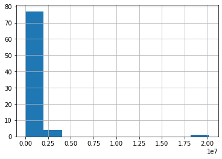

```python
df_describe['max'].hist(bins = 10)
```

```python
df_describe['max'].min()
```

```
0.941
```

```python
# 最大值分布
max_distribution = pd.cut(df_describe['max'],
                          bins=[0, 1.1, 10, 100, 1000, np.inf],
                          labels=['000-001', '001-010', '010-100', '100-1000', '1000+'])
```

```python
max_distribution.value_counts().sort_index()
```

```
000-001      9
001-010      3
010-100     32
100-1000    18
1000+       20
Name: max, dtype: int64
```

```python
max_distribution.head(10)
```

```
custid                                      1000+
low_volume_percent                        000-001
middle_volume_percent                     000-001
take_amount_in_later_12_month_highest       1000+
trans_amount_increase_rate_lately           1000+
trans_activity_month                      000-001
trans_activity_day                        000-001
transd_mcc                                010-100
trans_days_interval_filter               100-1000
trans_days_interval                      100-1000
Name: max, dtype: category
Categories (5, object): [000-001 < 001-010 < 010-100 < 100-1000 < 1000+]
```

```python
df_describe
```

|  | count | mean | std | min | 25% | 50% | 75% | max |
| --- | --- | --- | --- | --- | --- | --- | --- | --- |
| custid | 3327.0 | 1.685829e+06 | 1.039677e+06 | 1.140000e+02 | 754571.50 | 1623683.00 | 2.603724e+06 | 4.004694e+06 |
| low_volume_percent | 3325.0 | 2.206316e-02 | 4.144446e-02 | 0.000000e+00 | 0.01 | 0.01 | 2.000000e-02 | 1.000000e+00 |
| middle_volume_percent | 3325.0 | 9.024331e-01 | 1.434408e-01 | 0.000000e+00 | 0.88 | 0.96 | 9.900000e-01 | 1.000000e+00 |
| take_amount_in_later_12_month_highest | 3327.0 | 1.946736e+03 | 4.113834e+03 | 0.000000e+00 | 0.00 | 500.00 | 2.000000e+03 | 6.800000e+04 |
| trans_amount_increase_rate_lately | 3325.0 | 1.906549e+01 | 8.297462e+02 | 0.000000e+00 | 0.60 | 0.97 | 1.620000e+00 | 4.759674e+04 |
| trans_activity_month | 3325.0 | 8.068481e-01 | 1.964616e-01 | 1.200000e-01 | 0.67 | 0.86 | 1.000000e+00 | 1.000000e+00 |
| trans_activity_day | 3325.0 | 3.644478e-01 | 1.701654e-01 | 3.300000e-02 | 0.23 | 0.35 | 4.770000e-01 | 9.410000e-01 |
| transd_mcc | 3325.0 | 1.744632e+01 | 4.486967e+00 | 2.000000e+00 | 15.00 | 17.00 | 2.000000e+01 | 4.100000e+01 |
| trans_days_interval_filter | 3321.0 | 2.898073e+01 | 2.231557e+01 | 0.000000e+00 | 16.00 | 24.00 | 3.300000e+01 | 2.610000e+02 |
| trans_days_interval | 3325.0 | 2.167850e+01 | 1.643010e+01 | 5.000000e+00 | 12.00 | 17.00 | 2.600000e+01 | 2.340000e+02 |
| regional_mobility | 3325.0 | 2.656842e+00 | 8.877182e-01 | 1.000000e+00 | 2.00 | 3.00 | 3.000000e+00 | 5.000000e+00 |
| student_feature | 1208.0 | 1.000828e+00 | 2.877177e-02 | 1.000000e+00 | 1.00 | 1.00 | 1.000000e+00 | 2.000000e+00 |
| repayment_capability | 3327.0 | 1.914114e+04 | 5.854450e+04 | 0.000000e+00 | 8680.00 | 12240.00 | 1.769000e+04 | 2.459390e+06 |
| is_high_user | 3327.0 | 1.172227e-02 | 1.076492e-01 | 0.000000e+00 | 0.00 | 0.00 | 0.000000e+00 | 1.000000e+00 |
| number_of_trans_from_2011 | 3325.0 | 2.295850e+01 | 1.006304e+01 | 2.000000e+00 | 16.00 | 21.00 | 2.900000e+01 | 8.500000e+01 |
| first_transaction_time | 3325.0 | 2.015134e+07 | 1.470414e+04 | 2.011010e+07 | 20141022.00 | 20151115.00 | 2.016083e+07 | 2.018011e+07 |
| historical_trans_amount | 3327.0 | 2.265499e+05 | 2.429523e+05 | 0.000000e+00 | 78165.00 | 159480.00 | 2.971700e+05 | 4.008300e+06 |
| historical_trans_day | 3325.0 | 1.754662e+02 | 9.965845e+01 | 5.000000e+00 | 100.00 | 160.00 | 2.310000e+02 | 9.070000e+02 |
| rank_trad_1_month | 3325.0 | 4.786316e-01 | 2.647111e-01 | 5.000000e-02 | 0.30 | 0.45 | 6.000000e-01 | 1.000000e+00 |
| trans_amount_3_month | 3327.0 | 3.797162e+04 | 5.669435e+04 | 0.000000e+00 | 11420.00 | 25020.00 | 4.786000e+04 | 1.540890e+06 |
| avg_consume_less_12_valid_month | 3325.0 | 6.566015e+00 | 1.376566e+00 | 0.000000e+00 | 6.00 | 7.00 | 7.000000e+00 | 1.100000e+01 |
| abs | 3327.0 | 9.376375e+03 | 2.870614e+04 | 0.000000e+00 | 1255.00 | 3390.00 | 7.960000e+03 | 9.184500e+05 |
| top_trans_count_last_1_month | 3325.0 | 3.594436e-01 | 3.525664e-01 | 5.000000e-02 | 0.10 | 0.20 | 6.500000e-01 | 1.000000e+00 |
| avg_price_last_12_month | 3327.0 | 1.224151e+03 | 6.745982e+02 | 0.000000e+00 | 920.00 | 1140.00 | 1.390000e+03 | 1.412000e+04 |
| avg_price_top_last_12_valid_month | 3249.0 | 5.162512e-01 | 1.006398e-01 | 5.000000e-02 | 0.45 | 0.50 | 5.500000e-01 | 1.000000e+00 |
| trans_top_time_last_1_month | 3321.0 | 7.119542e+00 | 5.353851e+00 | 0.000000e+00 | 3.00 | 7.00 | 1.000000e+01 | 2.700000e+01 |
| trans_top_time_last_6_month | 3321.0 | 2.007919e+01 | 1.279244e+01 | 0.000000e+00 | 12.00 | 17.00 | 2.600000e+01 | 1.240000e+02 |
| consume_top_time_last_1_month | 3321.0 | 7.028907e+00 | 5.472693e+00 | 0.000000e+00 | 3.00 | 7.00 | 1.100000e+01 | 2.700000e+01 |
| consume_top_time_last_6_month | 3321.0 | 2.068022e+01 | 1.310574e+01 | 0.000000e+00 | 12.00 | 18.00 | 2.600000e+01 | 1.510000e+02 |
| cross_consume_count_last_1_month | 3037.0 | 6.269345e-01 | 2.173647e+00 | 0.000000e+00 | 0.00 | 0.00 | 1.000000e+00 | 6.900000e+01 |

[output cut: 52 more lines]

# 特征工程

## 特征预处理

任务1：对数据进行探索和分析。时间：2天

- 数据类型的分析
- 无关特征删除
- 数据类型转换
- 缺失值处理
- ……以及你能想到和借鉴的数据分析处理

```python
train_set = train_set.copy()
```

```python
status = train_set['status']
del train_set['status']
train_set['status'] = status
```

```python
train_set.shape
```

```
(3327, 89)
```

```python
for count, col in enumerate(train_set.columns):
    dtype = str(test_set[col].dtype)
    if dtype != 'object':
        col_min = test_set[col].min()
        col_max = test_set[col].max()
        print(f'{count:02d}  {col:45s}\t # [{dtype:6s} {col_min:,}-{col_max:,}]')
    else:
        print(f'{count:02d}  {col:45s}\t # [{dtype:10s}]')
        obj = train_set[col].value_counts().sort_index()
        print(obj.head(20))
    # break
```

```
00  custid                                       	 # [int64  2,244-3,832,193]
01  trade_no                                     	 # [object    ]
20180504155023833000000381228411    1
20180504155028091000000381224030    1
20180504155044450000000381226734    1
20180504155102497000000381226963    1
20180504155115618000000381228989    1
20180504155123490000000381229583    1
20180504155137627000000021137291    1
20180504155148729000000381229819    1
20180504155203298000000381229942    1
20180504155222051000000381233794    1
20180504155252113000000381239311    1
20180504155302404000000021136451    1
20180504155316469000000021138909    1
20180504155319956000000021136626    1
20180504155336144000000381241426    1
20180504155358051000000381239140    1
20180504155405877000000381243585    1
20180504155409262000000381248182    1
20180504155429742000000381243911    1
20180504155442259000000381244085    1
Name: trade_no, dtype: int64
02  bank_card_no                                 	 # [object    ]
卡号1    3327
Name: bank_card_no, dtype: int64
03  low_volume_percent                           	 # [float64 0.0-1.0]
04  middle_volume_percent                        	 # [float64 0.0-1.0]
05  take_amount_in_later_12_month_highest        	 # [int64  0-29,300]
06  trans_amount_increase_rate_lately            	 # [float64 0.0-301.47]
07  trans_activity_month                         	 # [float64 0.14-1.0]
08  trans_activity_day                           	 # [float64 0.05-0.925]
09  transd_mcc                                   	 # [float64 2.0-42.0]
10  trans_days_interval_filter                   	 # [float64 0.0-285.0]
11  trans_days_interval                          	 # [float64 4.0-151.0]
12  regional_mobility                            	 # [float64 1.0-5.0]
13  student_feature                              	 # [float64 1.0-2.0]
14  repayment_capability                         	 # [int64  20-834,920]
15  is_high_user                                 	 # [int64  0-1]
16  number_of_trans_from_2011                    	 # [float64 1.0-69.0]
```

[output cut: 128 more lines]

```
74  loans_credit_limit                           	 # [float64 0.0-6,900.0]
75  loans_credibility_limit                      	 # [float64 0.0-89.0]
76  loans_org_count_current                      	 # [float64 0.0-29.0]
77  loans_product_count                          	 # [float64 0.0-30.0]
78  loans_max_limit                              	 # [float64 0.0-10,000.0]
79  loans_avg_limit                              	 # [float64 0.0-6,900.0]
80  consfin_credit_limit                         	 # [float64 0.0-82,800.0]
81  consfin_credibility                          	 # [float64 0.0-87.0]
82  consfin_org_count_current                    	 # [float64 0.0-17.0]
83  consfin_product_count                        	 # [float64 0.0-20.0]
84  consfin_max_limit                            	 # [float64 0.0-152,400.0]
85  consfin_avg_limit                            	 # [float64 0.0-82,800.0]
86  latest_query_day                             	 # [float64 -2.0-360.0]
87  loans_latest_day                             	 # [float64 -2.0-313.0]
88  status                                       	 # [int64  0-1]
```

```python
# def col_describe(col):
#     if test_set[col].dtype != 'object':
#         print(train_set[col].describe())
#         print('-'*30)
#     obj = train_set[col].value_counts().sort_index()
#     if obj.shape[0] > 10:
#         print(obj.iloc[[0,1,2,3,-4, -3,-2,-1]])
#     else:
#         print(obj)

# for col in test_set.columns[19:28]:
#     print(col)
#     print('-'*30)
#     col_describe(col)
#     print('-'*30 + '\n\n')
```

```python
# test_set['reg_preference_for_trad'].replace(['境外', '一线城市', '二线城市', '三线城市', '其他城市'], [1,2,3,4,5])
```

### cols_to_del

```
[删除] 00  custid                                          # [删除] 顾客ID号 没有重复
[删除] 01  trade_no                                        # [删除] 交易号 没有重复(可能带有时间信息)
[删除] 02  bank_card_no                                    # [删除] 卡号均为1
[删除] 43  source                                          # [删除] 均为xs
[删除] 46  id_name                                         # [姓名    ]
```

```python
cols_to_del = train_set.columns[[0,1,2,43,46]]
cols_to_del
```

```
Index(['custid', 'trade_no', 'bank_card_no', 'source', 'id_name'], dtype='object')
```

### cols_0_to_1

```
[0-1] 03  low_volume_percent                             # [float64 0.0-1.0]
[0-1] 04  middle_volume_percent                          # [float64 0.0-1.0]
[0-1] 07  trans_activity_month                           # [float64 0.14-1.0]
[0-1] 08  trans_activity_day                             # [float64 0.05-0.925]
[0-1] 20  rank_trad_1_month                              # [float64 0.05-1.0]
[0-1] 24  top_trans_count_last_1_month                   # [float64 0.05-1.0]
[0-1] 26  avg_price_top_last_12_valid_month              # [float64 0.05-1.0]
```

```python
cols_0_to_1 = list(train_set.columns[[3,4,7,8,20,24,26]])
cols_0_to_1
```

```
['low_volume_percent',
 'middle_volume_percent',
 'trans_activity_month',
 'trans_activity_day',
 'rank_trad_1_month',
 'top_trans_count_last_1_month',
 'avg_price_top_last_12_valid_month']
```

### cols_catg

```
[分类] 12  regional_mobility                               # [分类(有序) 1，2，3，4，5] 区域流动性
[分类] 13  student_feature                                 # [分类 1,空, 2] 学生属性
[分类] 15  is_high_user                                    # [分类  0/1]
[分类] 27  reg_preference_for_trad                         # [object    ]
          test_set['reg_preference_for_trad'].replace(
                ['境外', '一线城市', '二线城市', '三线城市', '其他城市'],
                [1,2,3,4,5])
```

```python
cols_catg = list(train_set.columns[[12,13,15,27]])
cols_catg
```

```
['regional_mobility',
 'student_feature',
 'is_high_user',
 'reg_preference_for_trad']
```

### cols_date

```
[日期] 17  first_transaction_time                          # [date 格式 20170217.0] 第一次交易时间 20110101-20180114
[日期] 53  latest_query_time                               # [object  格式 2017-06-15 ]
[日期] 73  loans_latest_time                               # [object  格式 2017-06-15 ]
```

```python
cols_date = train_set.columns[[17,53,73]]
cols_date
```

```
Index(['first_transaction_time', 'latest_query_time', 'loans_latest_time'], dtype='object')
```

### cols_nums

```
05  take_amount_in_later_12_month_highest            # [int64  0-29,300]
06  trans_amount_increase_rate_lately                # [float64 0.0-301.47]

09  transd_mcc                                       # [float64 2.0-42.0]
10  trans_days_interval_filter                       # [int 0.0-285.0]
11  trans_days_interval                              # [int 4.0-151.0]
14  repayment_capability                             # [int64  20-834,920]
16  number_of_trans_from_2011                        # [int 1.0-69.0]
18  historical_trans_amount                          # [int64  0-13,601,300]
19  historical_trans_day                             # [int64 2.0-684.0]
21  trans_amount_3_month                             # [int64  0-6,024,100]
22  avg_consume_less_12_valid_month                  # [int64 0.0-11.0] 0,1,2,...,11
23  abs                                              # [int64  0-299,920]
25  avg_price_last_12_month                          # [int64  0-23,140]
28  trans_top_time_last_1_month                      # [float64 0.0-27.0]
29  trans_top_time_last_6_month                      # [float64 0.0-116.0]
30  consume_top_time_last_1_month                    # [float64 0.0-27.0]
31  consume_top_time_last_6_month                    # [float64 0.0-115.0]
32  cross_consume_count_last_1_month                 # [float64 0.0-66.0]
33  trans_fail_top_count_enum_last_1_month           # [float64 0.0-21.0]
34  trans_fail_top_count_enum_last_6_month           # [float64 0.0-48.0]
35  trans_fail_top_count_enum_last_12_month          # [float64 0.0-48.0]
36  consume_mini_time_last_1_month                   # [float64 0.0-2,392,316.0]
37  max_cumulative_consume_later_1_month             # [int64  0-345,280]
38  max_consume_count_later_6_month                  # [float64 0.0-48.0]
39  railway_consume_count_last_12_month              # [float64 0.0-4.0]
40  pawns_auctions_trusts_consume_last_1_month       # [int64  0-238,380]
41  pawns_auctions_trusts_consume_last_6_month       # [int64  0-496,980]
42  jewelry_consume_count_last_6_month               # [float64 0.0-5.0]
44  first_transaction_day                            # [float64 127.0-2,697.0]
45  trans_day_last_12_month                          # [float64 82.0-382.0]
47  apply_score                                      # [float64 484.0-683.0]
48  apply_credibility                                # [float64 50.0-93.0]
49  query_org_count                                  # [float64 1.0-37.0]
50  query_finance_count                              # [float64 0.0-20.0]
51  query_cash_count                                 # [float64 0.0-16.0]
52  query_sum_count                                  # [float64 1.0-87.0]
54  latest_one_month_apply                           # [float64 0.0-34.0]
55  latest_three_month_apply                         # [float64 0.0-75.0]
56  latest_six_month_apply                           # [float64 0.0-80.0]
57  loans_score                                      # [float64 413.0-680.0]
58  loans_credibility_behavior                       # [float64 57.0-85.0]
59  loans_count                                      # [float64 1.0-158.0]
60  loans_settle_count                               # [float64 0.0-154.0]
61  loans_overdue_count                              # [float64 0.0-25.0]
62  loans_org_count_behavior                         # [float64 1.0-40.0]
63  consfin_org_count_behavior                       # [float64 0.0-17.0]
64  loans_cash_count                                 # [float64 0.0-29.0]
65  latest_one_month_loan                            # [float64 0.0-13.0]
66  latest_three_month_loan                          # [float64 0.0-52.0]
67  latest_six_month_loan                            # [float64 0.0-64.0]
68  history_suc_fee                                  # [float64 0.0-254.0]
69  history_fail_fee                                 # [float64 0.0-345.0]
70  latest_one_month_suc                             # [float64 0.0-20.0]
71  latest_one_month_fail                            # [float64 0.0-58.0]
72  loans_long_time                                  # [float64 26.0-360.0]

74  loans_credit_limit                               # [float64 0.0-6,900.0]
75  loans_credibility_limit                          # [float64 0.0-89.0]
76  loans_org_count_current                          # [float64 0.0-29.0]
77  loans_product_count                              # [float64 0.0-30.0]
78  loans_max_limit                                  # [float64 0.0-10,000.0]
79  loans_avg_limit                                  # [float64 0.0-6,900.0]
80  consfin_credit_limit                             # [float64 0.0-82,800.0]
81  consfin_credibility                              # [float64 0.0-87.0]
82  consfin_org_count_current                        # [float64 0.0-17.0]
83  consfin_product_count                            # [float64 0.0-20.0]
84  consfin_max_limit                                # [float64 0.0-152,400.0]
85  consfin_avg_limit                                # [float64 0.0-82,800.0]
86  latest_query_day                                 # [float64 -2.0-360.0]
87  loans_latest_day                                 # [float64 -2.0-313.0]

[目标] 88  status                                          # [int64  0-1]
```

```python
# cols_0_to_1, cols_catg, cols_date, cols_to_del
```

```python
cols_others = []
for cols_list in (cols_0_to_1, cols_catg, cols_date, cols_to_del):
    cols_others.extend(list(cols_list))
```

```python
cols_others.append('status')
```

```python
len(cols_others)
```

```
20
```

```python
cols_nums = [col for col in train_set.columns if col not in cols_others]
```

```python
len(train_set.columns)
```

[output not shown]

```python
len(cols_nums)
```

[output not shown]

```python
cols_nums
```

```
['take_amount_in_later_12_month_highest',
 'trans_amount_increase_rate_lately',
 'transd_mcc',
 'trans_days_interval_filter',
 'trans_days_interval',
 'repayment_capability',
 'number_of_trans_from_2011',
 'historical_trans_amount',
 'historical_trans_day',
 'trans_amount_3_month',
 'avg_consume_less_12_valid_month',
 'abs',
 'avg_price_last_12_month',
 'trans_top_time_last_1_month',
 'trans_top_time_last_6_month',
 'consume_top_time_last_1_month',
 'consume_top_time_last_6_month',
 'cross_consume_count_last_1_month',
 'trans_fail_top_count_enum_last_1_month',
 'trans_fail_top_count_enum_last_6_month',
 'trans_fail_top_count_enum_last_12_month',
 'consume_mini_time_last_1_month',
 'max_cumulative_consume_later_1_month',
 'max_consume_count_later_6_month',
 'railway_consume_count_last_12_month',
 'pawns_auctions_trusts_consume_last_1_month',
 'pawns_auctions_trusts_consume_last_6_month',
 'jewelry_consume_count_last_6_month',
 'first_transaction_day',
 'trans_day_last_12_month',
 'apply_score',
 'apply_credibility',
 'query_org_count',
 'query_finance_count',
 'query_cash_count',
 'query_sum_count',
 'latest_one_month_apply',
 'latest_three_month_apply',
 'latest_six_month_apply',
 'loans_score',
```

[output cut: 17 more lines]

[output not shown]

## 处理空值

```python
obj = train_set.isnull().sum().sort_values(ascending=False)
obj[obj>0]
```

```
student_feature                            2119
cross_consume_count_last_1_month            290
query_finance_count                         220
latest_three_month_apply                    220
apply_score                                 220
apply_credibility                           220
query_org_count                             220
query_cash_count                            220
query_sum_count                             220
latest_query_time                           220
latest_one_month_apply                      220
latest_six_month_apply                      220
latest_query_day                            220
loans_org_count_current                     215
loans_settle_count                          215
loans_latest_day                            215
consfin_avg_limit                           215
consfin_max_limit                           215
consfin_product_count                       215
loans_credibility_limit                     215
consfin_credibility                         215
consfin_credit_limit                        215
loans_avg_limit                             215
loans_max_limit                             215
loans_product_count                         215
loans_score                                 215
loans_credibility_behavior                  215
loans_count                                 215
consfin_org_count_current                   215
loans_overdue_count                         215
history_suc_fee                             215
loans_credit_limit                          215
loans_org_count_behavior                    215
loans_long_time                             215
latest_one_month_fail                       215
latest_one_month_suc                        215
history_fail_fee                            215
loans_latest_time                           215
latest_six_month_loan                       215
latest_one_month_loan                       215
```

[output cut: 20 more lines]

```
trans_activity_day                            2
first_transaction_time                        2
transd_mcc                                    2
avg_consume_less_12_valid_month               2
trans_activity_month                          2
first_transaction_day                         2
trans_amount_increase_rate_lately             2
top_trans_count_last_1_month                  2
reg_preference_for_trad                       2
middle_volume_percent                         2
low_volume_percent                            2
trans_day_last_12_month                       2
trans_days_interval                           2
regional_mobility                             2
dtype: int64
```

### 删除2行缺失较多的行

```python
cond = train_set['first_transaction_day'].isnull()
train_set[cond].T
```

|  | 2703 | 3740 |
| --- | --- | --- |
| custid | 2346029 | 2123079 |
| trade_no | 20180507122903344000000023090358 | 20180507123543218000000023096586 |
| bank_card_no | 卡号1 | 卡号1 |
| low_volume_percent | NaN | NaN |
| middle_volume_percent | NaN | NaN |
| take_amount_in_later_12_month_highest | 0 | 0 |
| trans_amount_increase_rate_lately | NaN | NaN |
| trans_activity_month | NaN | NaN |
| trans_activity_day | NaN | NaN |
| transd_mcc | NaN | NaN |
| trans_days_interval_filter | NaN | NaN |
| trans_days_interval | NaN | NaN |
| regional_mobility | NaN | NaN |
| student_feature | NaN | NaN |
| repayment_capability | 0 | 0 |
| is_high_user | 0 | 0 |
| number_of_trans_from_2011 | NaN | NaN |
| first_transaction_time | NaN | NaN |
| historical_trans_amount | 0 | 0 |
| historical_trans_day | NaN | NaN |
| rank_trad_1_month | NaN | NaN |
| trans_amount_3_month | 0 | 0 |
| avg_consume_less_12_valid_month | NaN | NaN |
| abs | 0 | 0 |
| top_trans_count_last_1_month | NaN | NaN |
| avg_price_last_12_month | 0 | 0 |
| avg_price_top_last_12_valid_month | NaN | NaN |
| reg_preference_for_trad | NaN | NaN |
| trans_top_time_last_1_month | NaN | NaN |
| trans_top_time_last_6_month | NaN | NaN |

[output cut: 59 more lines]

```python
train_set = train_set[~cond].copy()
```

### 分类类型缺失值处理

student_feature缺失值处理

```python
train_set['student_feature'].value_counts()
```

```
1.0    1207
2.0       1
Name: student_feature, dtype: int64
```

```python
# 空值填充为0
train_set['student_feature'] = train_set['student_feature'].fillna(0).astype(int)
```

```python
cols_catg
```

[output not shown]

```python
obj_null = train_set.isnull().sum()
obj_null[obj_null>0].head()
```

```
trans_days_interval_filter            4
avg_price_top_last_12_valid_month    76
trans_top_time_last_1_month           4
trans_top_time_last_6_month           4
consume_top_time_last_1_month         4
dtype: int64
```

```python
# 分类空值处理完毕
obj_null[cols_catg]
```

```
regional_mobility          0
student_feature            0
is_high_user               0
reg_preference_for_trad    0
dtype: int64
```

#### cols_catg

```
[分类] 12  regional_mobility                                 # [分类(有序) 1，2，3，4，5] 区域流动性
[分类] 13  student_feature                                   # [分类 1,空, 2] 学生属性
[分类] 15  is_high_user                                      # [分类  0/1]
[分类] 27  reg_preference_for_trad                           # [object    ]
          test_set['reg_preference_for_trad'].replace(
                ['境外', '一线城市', '二线城市', '三线城市', '其他城市'],
                [1,2,3,4,5])
```

```python
cols_catg
```

[output not shown]

reg_preference_for_trad

```python
col = 'reg_preference_for_trad'
train_set[col] = train_set[col].replace(
                    ['境外', '一线城市', '二线城市', '三线城市', '其他城市'],
                    [1,2,3,4,5])
```

```python
train_set[cols_catg].head()
```

|  | regional_mobility | student_feature | is_high_user | reg_preference_for_trad |
| --- | --- | --- | --- | --- |
| 110 | 1.0 | 1 | 0 | 2 |
| 3394 | 3.0 | 0 | 0 | 2 |
| 3052 | 2.0 | 0 | 0 | 2 |
| 490 | 4.0 | 1 | 0 | 4 |
| 1 | 4.0 | 1 | 0 | 2 |

regional_mobility

```python
train_set.regional_mobility = train_set.regional_mobility.astype(int)
```

student_feature == 2 唯一一个

```python
cond = train_set.student_feature > 1
train_set[cond].T
```

|  | 2991 |
| --- | --- |
| custid | 2229219 |
| trade_no | 20180507123630913000000388369982 |
| bank_card_no | 卡号1 |
| low_volume_percent | 0.02 |
| middle_volume_percent | 0.98 |
| take_amount_in_later_12_month_highest | 2500 |
| trans_amount_increase_rate_lately | 1.17 |
| trans_activity_month | 0.8 |
| trans_activity_day | 0.319 |
| transd_mcc | 21 |
| trans_days_interval_filter | 26 |
| trans_days_interval | 15 |
| regional_mobility | 4 |
| student_feature | 2 |
| repayment_capability | 21020 |
| is_high_user | 0 |
| number_of_trans_from_2011 | 35 |
| first_transaction_time | 2.01407e+07 |
| historical_trans_amount | 94690 |
| historical_trans_day | 181 |
| rank_trad_1_month | 0.3 |
| trans_amount_3_month | 16320 |
| avg_consume_less_12_valid_month | 7 |
| abs | 4180 |
| top_trans_count_last_1_month | 0.15 |
| avg_price_last_12_month | 1050 |
| avg_price_top_last_12_valid_month | 0.55 |
| reg_preference_for_trad | 2 |
| trans_top_time_last_1_month | 11 |
| trans_top_time_last_6_month | 12 |

[output cut: 59 more lines]

```python
# 转为0
train_set.loc[cond, 'student_feature'] = 0
```

```python
for col in cols_catg:
    print(train_set[col].value_counts())
    print('-'*30 + '\n')
```

```
3    1364
2    1076
4     535
1     325
5      25
Name: regional_mobility, dtype: int64
------------------------------

0    2118
1    1207
Name: student_feature, dtype: int64
------------------------------

0    3286
1      39
Name: is_high_user, dtype: int64
------------------------------

2    2380
4     747
1     103
3      92
5       3
Name: reg_preference_for_trad, dtype: int64
------------------------------
```

### cols_date 日期型数据处理

```python
cols_date
```

```
Index(['first_transaction_time', 'latest_query_time', 'loans_latest_time'], dtype='object')
```

```python
train_set[cols_date].isnull().sum()
```

```
first_transaction_time      0
latest_query_time         220
loans_latest_time         215
dtype: int64
```

```python
train_set['first_transaction_time'].max()
```

```
20180114.0
```

```python
train_set['first_transaction_time'].head()
```

```
110     20170217.0
3394    20170331.0
3052    20141110.0
490     20130817.0
1       20160402.0
Name: first_transaction_time, dtype: float64
```

```python
train_set['first_transaction_time'] = pd.to_datetime(train_set['first_transaction_time'].astype(int).astype(str))
```

```python
for col in cols_date:
    train_set[col] = pd.to_datetime(train_set[col])
```

```python
train_set[cols_date].isnull().sum()
```

```
first_transaction_time      0
latest_query_time         220
loans_latest_time         215
dtype: int64
```

```python
train_set[cols_date].min()
```

```
first_transaction_time   2011-01-01
latest_query_time        2017-05-13
loans_latest_time        2017-06-15
dtype: datetime64[ns]
```

```python
train_set[cols_date].max()
```

```
first_transaction_time   2018-01-14
latest_query_time        2018-05-07
loans_latest_time        2018-05-06
dtype: datetime64[ns]
```

时间取离2018-06-01相关的天数，空值取-999

```python
cols_date_diff = [col+'_diff_day' for col in cols_date]
cols_date_diff
```

```
['first_transaction_time_diff_day',
 'latest_query_time_diff_day',
 'loans_latest_time_diff_day']
```

```python
train_set['first_transaction_time_diff_day']
```

[output not shown]

```python
for col, col_d in zip(cols_date_diff, cols_date):
    train_set[col] = ((pd.to_datetime('2018-06-01') - train_set[col_d])
                          .dt.days
                          .fillna(-999)
                          .astype(int))
```

```python
train_set[cols_date_diff].head()
```

|  | first_transaction_time_diff_day | latest_query_time_diff_day | loans_latest_time_diff_day |
| --- | --- | --- | --- |
| 110 | 469 | 28 | 37 |
| 3394 | 427 | 55 | 52 |
| 3052 | 1299 | 28 | 162 |
| 490 | 1749 | 45 | 76 |
| 1 | 790 | 29 | 27 |

```python
train_set[cols_date_diff].isnull().sum()
```

```
first_transaction_time_diff_day    0
latest_query_time_diff_day         0
loans_latest_time_diff_day         0
dtype: int64
```

### cols_0_to_1

```python
train_set[cols_0_to_1].isnull().sum()
```

```
low_volume_percent                    0
middle_volume_percent                 0
trans_activity_month                  0
trans_activity_day                    0
rank_trad_1_month                     0
top_trans_count_last_1_month          0
avg_price_top_last_12_valid_month    76
dtype: int64
```

```python
train_set['avg_price_top_last_12_valid_month'].describe()
```

```
count    3249.000000
mean        0.516251
std         0.100640
min         0.050000
25%         0.450000
50%         0.500000
75%         0.550000
max         1.000000
Name: avg_price_top_last_12_valid_month, dtype: float64
```

```python
train_set['avg_price_top_last_12_valid_month'] = train_set['avg_price_top_last_12_valid_month'].fillna(-1)
```

```python
train_set[cols_0_to_1].isnull().sum()
```

```
low_volume_percent                   0
middle_volume_percent                0
trans_activity_month                 0
trans_activity_day                   0
rank_trad_1_month                    0
top_trans_count_last_1_month         0
avg_price_top_last_12_valid_month    0
dtype: int64
```

### cols_nums

```python
print(cols_nums)
```

[output not shown]

```python
obj = train_set[cols_nums].isnull().sum()
obj[obj>0]
```

```
trans_days_interval_filter                   4
trans_top_time_last_1_month                  4
trans_top_time_last_6_month                  4
consume_top_time_last_1_month                4
consume_top_time_last_6_month                4
cross_consume_count_last_1_month           288
trans_fail_top_count_enum_last_1_month      11
trans_fail_top_count_enum_last_6_month      11
trans_fail_top_count_enum_last_12_month     11
consume_mini_time_last_1_month              13
max_consume_count_later_6_month              4
railway_consume_count_last_12_month          6
jewelry_consume_count_last_6_month           6
apply_score                                220
apply_credibility                          220
query_org_count                            220
query_finance_count                        220
query_cash_count                           220
query_sum_count                            220
latest_one_month_apply                     220
latest_three_month_apply                   220
latest_six_month_apply                     220
loans_score                                215
loans_credibility_behavior                 215
loans_count                                215
loans_settle_count                         215
loans_overdue_count                        215
loans_org_count_behavior                   215
consfin_org_count_behavior                 215
loans_cash_count                           215
latest_one_month_loan                      215
latest_three_month_loan                    215
latest_six_month_loan                      215
history_suc_fee                            215
history_fail_fee                           215
latest_one_month_suc                       215
latest_one_month_fail                      215
loans_long_time                            215
loans_credit_limit                         215
loans_credibility_limit                    215
loans_org_count_current                    215
loans_product_count                        215
loans_max_limit                            215
loans_avg_limit                            215
consfin_credit_limit                       215
consfin_credibility                        215
consfin_org_count_current                  215
consfin_product_count                      215
consfin_max_limit                          215
consfin_avg_limit                          215
latest_query_day                           220
loans_latest_day                           215
dtype: int64
```

#### cols_nums_with_day

天数相关的列

```python
cols_nums_with_day = [col for col in obj[obj>0].index if 'day' in col]
cols_nums_with_day
```

```
['trans_days_interval_filter', 'latest_query_day', 'loans_latest_day']
```

```python
cols_date
```

```
Index(['first_transaction_time', 'latest_query_time', 'loans_latest_time'], dtype='object')
```

```python
cols_date_diff
```

```
['first_transaction_time_diff_day',
 'latest_query_time_diff_day',
 'loans_latest_time_diff_day']
```

```python
cond = train_set['latest_query_day'].isnull()
train_set.loc[cond, cols_nums_with_day+cols_date_diff].head()
```

|  | trans_days_interval_filter | latest_query_day | loans_latest_day | first_transaction_time_diff_day | latest_query_time_diff_day | loans_latest_time_diff_day |
| --- | --- | --- | --- | --- | --- | --- |
| 4567 | 52.0 | NaN | 162.0 | 901 | -999 | 187 |
| 3635 | 20.0 | NaN | NaN | 393 | -999 | -999 |
| 3338 | 26.0 | NaN | NaN | 793 | -999 | -999 |
| 1888 | 28.0 | NaN | NaN | 1053 | -999 | -999 |
| 876 | 40.0 | NaN | NaN | 693 | -999 | -999 |

填充为-999

```python
train_set[cols_nums_with_day] = train_set[cols_nums_with_day].fillna(-999)
```

#### 其余填充为中位数

```python
obj = train_set[cols_nums].isnull().sum()
cols_nums_fillna = obj[obj>0].index
```

```python
cols_nums_fillna
```

```
Index(['trans_top_time_last_1_month', 'trans_top_time_last_6_month',
       'consume_top_time_last_1_month', 'consume_top_time_last_6_month',
       'cross_consume_count_last_1_month',
       'trans_fail_top_count_enum_last_1_month',
       'trans_fail_top_count_enum_last_6_month',
       'trans_fail_top_count_enum_last_12_month',
       'consume_mini_time_last_1_month', 'max_consume_count_later_6_month',
       'railway_consume_count_last_12_month',
       'jewelry_consume_count_last_6_month', 'apply_score',
       'apply_credibility', 'query_org_count', 'query_finance_count',
       'query_cash_count', 'query_sum_count', 'latest_one_month_apply',
       'latest_three_month_apply', 'latest_six_month_apply', 'loans_score',
       'loans_credibility_behavior', 'loans_count', 'loans_settle_count',
       'loans_overdue_count', 'loans_org_count_behavior',
       'consfin_org_count_behavior', 'loans_cash_count',
       'latest_one_month_loan', 'latest_three_month_loan',
       'latest_six_month_loan', 'history_suc_fee', 'history_fail_fee',
       'latest_one_month_suc', 'latest_one_month_fail', 'loans_long_time',
       'loans_credit_limit', 'loans_credibility_limit',
       'loans_org_count_current', 'loans_product_count', 'loans_max_limit',
       'loans_avg_limit', 'consfin_credit_limit', 'consfin_credibility',
       'consfin_org_count_current', 'consfin_product_count',
       'consfin_max_limit', 'consfin_avg_limit'],
      dtype='object')
```

```python
# 填充为中位数
for col in cols_nums_fillna:
    train_set[col] = train_set[col].fillna(train_set[col].median())
```

```python
train_set.isnull().sum()
```

```
custid                                          0
trade_no                                        0
bank_card_no                                    0
low_volume_percent                              0
middle_volume_percent                           0
take_amount_in_later_12_month_highest           0
trans_amount_increase_rate_lately               0
trans_activity_month                            0
trans_activity_day                              0
transd_mcc                                      0
trans_days_interval_filter                      0
trans_days_interval                             0
regional_mobility                               0
student_feature                                 0
repayment_capability                            0
is_high_user                                    0
number_of_trans_from_2011                       0
first_transaction_time                          0
historical_trans_amount                         0
historical_trans_day                            0
rank_trad_1_month                               0
trans_amount_3_month                            0
avg_consume_less_12_valid_month                 0
abs                                             0
top_trans_count_last_1_month                    0
avg_price_last_12_month                         0
avg_price_top_last_12_valid_month               0
reg_preference_for_trad                         0
trans_top_time_last_1_month                     0
trans_top_time_last_6_month                     0
consume_top_time_last_1_month                   0
consume_top_time_last_6_month                   0
cross_consume_count_last_1_month                0
trans_fail_top_count_enum_last_1_month          0
trans_fail_top_count_enum_last_6_month          0
trans_fail_top_count_enum_last_12_month         0
consume_mini_time_last_1_month                  0
max_cumulative_consume_later_1_month            0
max_consume_count_later_6_month                 0
railway_consume_count_last_12_month             0
```

[output cut: 38 more lines]

```
loans_max_limit                                 0
loans_avg_limit                                 0
consfin_credit_limit                            0
consfin_credibility                             0
consfin_org_count_current                       0
consfin_product_count                           0
consfin_max_limit                               0
consfin_avg_limit                               0
latest_query_day                                0
loans_latest_day                                0
status                                          0
first_transaction_time_diff_day                 0
latest_query_time_diff_day                      0
loans_latest_time_diff_day                      0
dtype: int64
```

# 特征权重

## IV值

https://medium.com/@sundarstyles89/weight-of-evidence-and-information-value-using-python-6f05072e83eb

Weight of evidence (WOE) and Information value (IV) are simple, yet powerful techniques to perform variable transformation and selection. These concepts have huge connection with the logistic regression modeling technique. It is widely used in credit scoring to measure the separation of good vs bad customers.

[github_code](https://github.com/Sundar0989/WOE-and-IV?source=post_page---------------------------)

调用他人写好的脚本

```python
# import packages
import pandas as pd
import numpy as np
import pandas.core.algorithms as algos
from pandas import Series
import scipy.stats.stats as stats
import re
import traceback
import string

max_bin = 20
force_bin = 3

# define a binning function
def mono_bin(Y, X, n = max_bin):

    df1 = pd.DataFrame({"X": X, "Y": Y})
    justmiss = df1[['X','Y']][df1.X.isnull()]
    notmiss = df1[['X','Y']][df1.X.notnull()]
    r = 0
    while np.abs(r) < 1:
        try:
            d1 = pd.DataFrame({"X": notmiss.X, "Y": notmiss.Y, "Bucket": pd.qcut(notmiss.X, n)})
            d2 = d1.groupby('Bucket', as_index=True)
            r, p = stats.spearmanr(d2.mean().X, d2.mean().Y)
            n = n - 1
        except Exception as e:
            n = n - 1

    if len(d2) == 1:
        n = force_bin
        bins = algos.quantile(notmiss.X, np.linspace(0, 1, n))
        if len(np.unique(bins)) == 2:
            bins = np.insert(bins, 0, 1)
            bins[1] = bins[1]-(bins[1]/2)
        d1 = pd.DataFrame({"X": notmiss.X, "Y": notmiss.Y, "Bucket": pd.cut(notmiss.X, np.unique(bins),include_lowest=True)})
        d2 = d1.groupby('Bucket', as_index=True)

    d3 = pd.DataFrame({},index=[])
    d3["MIN_VALUE"] = d2.min().X
    d3["MAX_VALUE"] = d2.max().X
    d3["COUNT"] = d2.count().Y
    d3["EVENT"] = d2.sum().Y
    d3["NONEVENT"] = d2.count().Y - d2.sum().Y
    d3=d3.reset_index(drop=True)

    if len(justmiss.index) > 0:
        d4 = pd.DataFrame({'MIN_VALUE':np.nan},index=[0])
        d4["MAX_VALUE"] = np.nan
        d4["COUNT"] = justmiss.count().Y
        d4["EVENT"] = justmiss.sum().Y
        d4["NONEVENT"] = justmiss.count().Y - justmiss.sum().Y
        d3 = d3.append(d4,ignore_index=True)

    d3["EVENT_RATE"] = d3.EVENT/d3.COUNT
    d3["NON_EVENT_RATE"] = d3.NONEVENT/d3.COUNT
    d3["DIST_EVENT"] = d3.EVENT/d3.sum().EVENT
    d3["DIST_NON_EVENT"] = d3.NONEVENT/d3.sum().NONEVENT
    d3["WOE"] = np.log(d3.DIST_EVENT/d3.DIST_NON_EVENT)
    d3["IV"] = (d3.DIST_EVENT-d3.DIST_NON_EVENT)*np.log(d3.DIST_EVENT/d3.DIST_NON_EVENT)
    d3["VAR_NAME"] = "VAR"
    d3 = d3[['VAR_NAME','MIN_VALUE', 'MAX_VALUE', 'COUNT', 'EVENT', 'EVENT_RATE', 'NONEVENT', 'NON_EVENT_RATE', 'DIST_EVENT','DIST_NON_EVENT','WOE', 'IV']]
    d3 = d3.replace([np.inf, -np.inf], 0)
    d3.IV = d3.IV.sum()

    return(d3)

def char_bin(Y, X):

    df1 = pd.DataFrame({"X": X, "Y": Y})
    justmiss = df1[['X','Y']][df1.X.isnull()]
    notmiss = df1[['X','Y']][df1.X.notnull()]
    df2 = notmiss.groupby('X',as_index=True)

    d3 = pd.DataFrame({},index=[])
    d3["COUNT"] = df2.count().Y
    d3["MIN_VALUE"] = df2.sum().Y.index
    d3["MAX_VALUE"] = d3["MIN_VALUE"]
    d3["EVENT"] = df2.sum().Y
    d3["NONEVENT"] = df2.count().Y - df2.sum().Y

    if len(justmiss.index) > 0:
        d4 = pd.DataFrame({'MIN_VALUE':np.nan},index=[0])
        d4["MAX_VALUE"] = np.nan
        d4["COUNT"] = justmiss.count().Y
        d4["EVENT"] = justmiss.sum().Y
        d4["NONEVENT"] = justmiss.count().Y - justmiss.sum().Y
        d3 = d3.append(d4,ignore_index=True)

    d3["EVENT_RATE"] = d3.EVENT/d3.COUNT
    d3["NON_EVENT_RATE"] = d3.NONEVENT/d3.COUNT
    d3["DIST_EVENT"] = d3.EVENT/d3.sum().EVENT
    d3["DIST_NON_EVENT"] = d3.NONEVENT/d3.sum().NONEVENT
    d3["WOE"] = np.log(d3.DIST_EVENT/d3.DIST_NON_EVENT)
    d3["IV"] = (d3.DIST_EVENT-d3.DIST_NON_EVENT)*np.log(d3.DIST_EVENT/d3.DIST_NON_EVENT)
    d3["VAR_NAME"] = "VAR"
    d3 = d3[['VAR_NAME','MIN_VALUE', 'MAX_VALUE', 'COUNT', 'EVENT', 'EVENT_RATE', 'NONEVENT', 'NON_EVENT_RATE', 'DIST_EVENT','DIST_NON_EVENT','WOE', 'IV']]
    d3 = d3.replace([np.inf, -np.inf], 0)
    d3.IV = d3.IV.sum()
    d3 = d3.reset_index(drop=True)

    return(d3)

def data_vars(df1, target):

    stack = traceback.extract_stack()
    filename, lineno, function_name, code = stack[-2]
    vars_name = re.compile(r'\((.*?)\).*$').search(code).groups()[0]
    final = (re.findall(r"[\w']+", vars_name))[-1]

    x = df1.dtypes.index
    count = -1

    for i in x:
        if i.upper() not in (final.upper()):
            if np.issubdtype(df1[i], np.number) and len(Series.unique(df1[i])) > 2:
                conv = mono_bin(target, df1[i])
                conv["VAR_NAME"] = i
                count = count + 1
            else:
                conv = char_bin(target, df1[i])
                conv["VAR_NAME"] = i
                count = count + 1

            if count == 0:
                iv_df = conv
            else:
                iv_df = iv_df.append(conv,ignore_index=True)

    iv = pd.DataFrame({'IV':iv_df.groupby('VAR_NAME').IV.max()})
    iv = iv.reset_index()
    return(iv_df,iv)
```

```python
train_set.columns
```

```
Index(['custid', 'trade_no', 'bank_card_no', 'low_volume_percent',
       'middle_volume_percent', 'take_amount_in_later_12_month_highest',
       'trans_amount_increase_rate_lately', 'trans_activity_month',
       'trans_activity_day', 'transd_mcc', 'trans_days_interval_filter',
       'trans_days_interval', 'regional_mobility', 'student_feature',
       'repayment_capability', 'is_high_user', 'number_of_trans_from_2011',
       'first_transaction_time', 'historical_trans_amount',
       'historical_trans_day', 'rank_trad_1_month', 'trans_amount_3_month',
       'avg_consume_less_12_valid_month', 'abs',
       'top_trans_count_last_1_month', 'avg_price_last_12_month',
       'avg_price_top_last_12_valid_month', 'reg_preference_for_trad',
       'trans_top_time_last_1_month', 'trans_top_time_last_6_month',
       'consume_top_time_last_1_month', 'consume_top_time_last_6_month',
       'cross_consume_count_last_1_month',
       'trans_fail_top_count_enum_last_1_month',
       'trans_fail_top_count_enum_last_6_month',
       'trans_fail_top_count_enum_last_12_month',
       'consume_mini_time_last_1_month',
       'max_cumulative_consume_later_1_month',
       'max_consume_count_later_6_month',
       'railway_consume_count_last_12_month',
       'pawns_auctions_trusts_consume_last_1_month',
       'pawns_auctions_trusts_consume_last_6_month',
       'jewelry_consume_count_last_6_month', 'source', 'first_transaction_day',
       'trans_day_last_12_month', 'id_name', 'apply_score',
       'apply_credibility', 'query_org_count', 'query_finance_count',
       'query_cash_count', 'query_sum_count', 'latest_query_time',
       'latest_one_month_apply', 'latest_three_month_apply',
       'latest_six_month_apply', 'loans_score', 'loans_credibility_behavior',
       'loans_count', 'loans_settle_count', 'loans_overdue_count',
       'loans_org_count_behavior', 'consfin_org_count_behavior',
       'loans_cash_count', 'latest_one_month_loan', 'latest_three_month_loan',
       'latest_six_month_loan', 'history_suc_fee', 'history_fail_fee',
       'latest_one_month_suc', 'latest_one_month_fail', 'loans_long_time',
       'loans_latest_time', 'loans_credit_limit', 'loans_credibility_limit',
       'loans_org_count_current', 'loans_product_count', 'loans_max_limit',
       'loans_avg_limit', 'consfin_credit_limit', 'consfin_credibility',
       'consfin_org_count_current', 'consfin_product_count',
       'consfin_max_limit', 'consfin_avg_limit', 'latest_query_day',
       'loans_latest_day', 'status', 'first_transaction_time_diff_day',
       'latest_query_time_diff_day', 'loans_latest_time_diff_day'],
      dtype='object')
```